# Multi-Sample Processing and Batch-Correction

Authors

Maximilian Nuber

Junyan Lu

This notebook is designed to guide you through the transition from analyzing a single sample to handling a complex, multi-sample experiment.

In single-cell biology, we rarely analyze just one donor. We compare Healthy vs. Disease, Wild-Type vs. Knockout, or Timepoints. However, when you combine these samples, you encounter the “Batch Effect”—the single biggest hurdle in single-cell bioinformatics.

1. The Concept: What is a Batch Effect?

Imagine you take a blood sample from a donor on Monday and process it. On Tuesday, you do the same for a second donor. Even if the donors are identical twins, the “Tuesday” cells will likely cluster separately from the “Monday” cells.

- Why? Differences in room temperature, pipetting speed, reagent lots, or sequencing depth.
- The Danger: If you don’t correct this, your computer will tell you that Monday’s donor and Tuesday’s donor are “different species,” masking the actual biology.
2. Setting Up: Data for Multi-Sample Analysis

To make this realistic, we will use the scrnaseq package (the Python counterpart to the Bioconductor R package) to fetch two classic datasets of the human pancreas. These datasets were produced by different labs using different technologies, making them perfect for demonstrating “Batch Effects.”

Multi-Sample Integration & Batch Correction 1. The Challenge: What is a Batch Effect?

In single-cell biology, a Batch Effect is technical noise that overrides biological signal. If you sequence the same patient’s blood on two different days, the “Monday cells” and “Tuesday cells” will often look different to a computer due to minor variations in temperature, reagents, or pipetting.

The Goal: We want the T-cells from Donor A to overlap with the T-cells from Donor B, while keeping the “Disease” cells separate from the “Healthy” cells.

2. Loading Real Data from the scrnaseq Package

We will use the scrnaseq package to pull two human pancreas datasets: Baron (2016) and Muraro (2016). These are provided as SingleCellExperiment objects, which we will convert to AnnData for use with Scanpy.

```python
import sys
sys.version
```

```
'3.13.13 | packaged by conda-forge | (main, Apr  8 2026, 02:00:33) [GCC 14.3.0]'
```

```python
import scvi
```

```python
import scrnaseq
import scanpy as sc
import anndata as ad

# 1. Fetch two different pancreas datasets (Human)
# These represent different 'batches' from different studies
sce_baron = scrnaseq.fetch_dataset("baron-pancreas-2016", "2023-12-14", path="human")
sce_muraro = scrnaseq.fetch_dataset("muraro-pancreas-2016", "2023-12-19")

# 2. Convert them to the AnnData format (used by Scanpy)
adata_baron = sce_baron.to_anndata()[0]
adata_muraro = sce_muraro.to_anndata()[0]
adata_baron.X = adata_baron.layers["counts"].copy() # `to_anndata()` doesn´iit populate .X
adata_muraro.X = adata_muraro.layers["counts"].copy()

# to keep memory manageable, delete:
del sce_baron
del sce_muraro

# fixing the gene names:
adata_muraro.var_names = [x.split("__")[0] for x in adata_muraro.var_names]

adata_baron.var_names_make_unique()
adata_muraro.var_names_make_unique()

# 3. Add metadata so we can track the origin of the cells
adata_baron.obs['study'] = 'Baron'
adata_muraro.obs['study'] = 'Muraro'

# 4. Combine (Concatenate) them into one object
# We keep only the genes found in both datasets (the 'inner' join)
adata = ad.concat([adata_baron, adata_muraro], join='inner')

# delete again:
# del adata_baron
# del adata_muraro
```

3. Visualizing the Problem: The “Raw” Merge

Before fixing anything, let’s look at the data. We follow the standard pipeline (Normalize -> PCA -> UMAP) on the combined data.

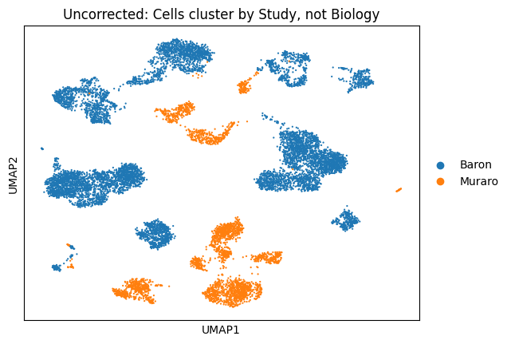

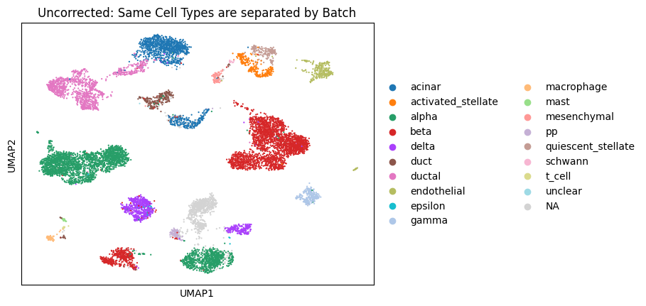

```python
# Standard Preprocessing
sc.pp.normalize_total(adata, target_sum=1e4)
sc.pp.log1p(adata)
sc.pp.highly_variable_genes(adata, n_top_genes=2000, batch_key='study')

# Dimensionality Reduction
sc.pp.pca(adata)
sc.pp.neighbors(adata)
sc.tl.umap(adata)

# Visualization
sc.pl.umap(adata, color=['study'], title='Uncorrected: Cells cluster by Study, not Biology')
sc.pl.umap(adata, color=['label'], title='Uncorrected: Same Cell Types are separated by Batch')
```

4. The Solutions: Harmony and Scanorama

To fix this, we use Integration algorithms. It is vital to understand what they change in your data. Method A: Harmony (The PCA-nudge)

Harmony is the industry standard for biologists. It assumes your gene expression is mostly okay, but the “coordinates” of the cells in PCA space are slightly off. It “nudges” the clusters together in the background.

- Changes: Only the obsm (PCA coordinates).
- Gene Expression: Remains untouched.

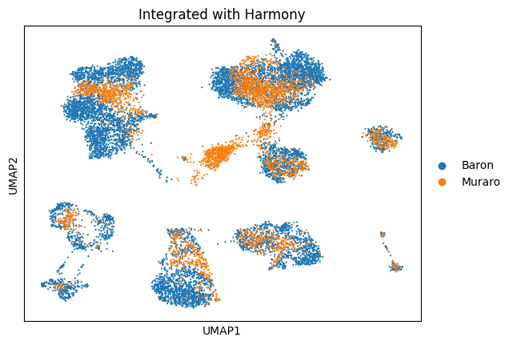

```python
import scanpy.external as sce
import harmonypy

# 1. Run Harmony based on the 'study' column
# THis doesn´t work currently:
# sce.pp.harmony_integrate(adata, key='study', basis='X_pca', adjusted_basis='X_pca_harmony')
import harmonypy
adjusted = "X_pca_harmony"
x = adata.obsm["X_pca"]
harmony_out = harmonypy.run_harmony(x, adata.obs, "study",)
adata.obsm[adjusted] = harmony_out.Z_corr

# 2. Re-run the map using the NEW 'harmony' coordinates
sc.pp.neighbors(adata, use_rep='X_pca_harmony')
sc.tl.umap(adata)
sc.pl.umap(adata, color=['study'], title='Integrated with Harmony')
```

Method B: Scanorama (The Gene-Stitcher)

Scanorama is more powerful for very different datasets. It looks for “mutual nearest neighbors” between datasets and can actually create a corrected gene expression matrix. The idea is borrowed from image processing. Different datasets are stitched together like photos in a panorama photo.

- Changes: Can create a whole new corrected expression layer.
- Use case: When combining vastly different technologies (e.g., 10x Genomics vs. Smart-seq2).

```
[[0.        0.6969401]
 [0.        0.       ]]
Processing datasets Baron <=> Muraro
```

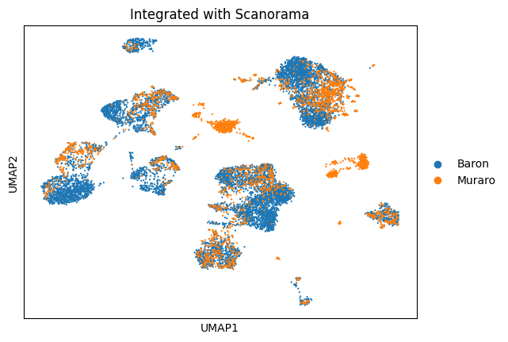

```python
# Scanorama integrates and returns a 'corrected' version of the PCA
sce.pp.scanorama_integrate(adata, key='study')

sc.pp.neighbors(adata, use_rep='X_scanorama')
sc.tl.umap(adata)
sc.pl.umap(adata, color=['study'], title='Integrated with Scanorama')
```

5. Which Data Structure should I use?

This is the most confusing part for new users. After integration, your AnnData object has multiple versions of the same data.

| Data Slot | Content | Batch Effect Present? | Primary Use Case |
| --- | --- | --- | --- |
| **`adata.X`** | Normalized & Logged Counts | **Yes** | **Differential Expression:** Use this for t-tests, finding marker genes, and calculating Fold Change. |
| **`adata.obsm['X_pca']`** | Raw Principal Components | **Yes** | **QC Only:** Use this to visualize the extent of the batch effect before you fix it. |
| **`adata.obsm['X_pca_harmony']`** | Integrated/Corrected Coordinates | **No** | **Clustering & UMAP:** Use this to define your cell types and make your “pretty” plots where samples overlap. |
| **`adata.layers['counts']`** | Raw, Integer Counts | **Yes** | **Specialized Tools:** Some packages (like `Scvi-tools` or `DoubletFinder`) require the raw, un-normalized UMI counts. |

**CRITICAL RULE**: Never use integrated/corrected counts for finding marker genes or calculating “Fold Change.” Integration is for grouping and seeing your cells. For the actual math of “Is Gene X higher in Disease?”, always go back to the original normalized counts in adata.X.

Summary for the Lab

- Merge your samples with ad.concat.
- Check for batch effects by coloring your UMAP by Sample/Donor/Study.
- Integrate using Harmony if you see samples separating by “Batch” rather than “Cell Type.”
- Cluster and Visualize using the integrated coordinates.
- Verify markers using the raw counts.
7. Choosing Your Integration Level: Dataset vs. Donor

In a complex experiment, you usually have a hierarchy of variation. You need to decide if you are correcting for major technical shifts (Dataset level) or individual biological variation (Donor level). Level 1: The Dataset (Study) Level

Use this when you are merging data from different labs or different technologies (e.g., 10x Genomics vs. Seq-Well).

- The Goal: Make the “Baron Pancreas” look like the “Muraro Pancreas.”
- The Risk: Low. These datasets are almost always technically different.

Level 2: The Donor (Sample) Level

Use this when you have multiple biological replicates (e.g., 6 different human patients) within the same study.

- The Goal: Prevent “Patient 1” cells from forming their own cluster separate from “Patient 2” cells just because of individual genetic backgrounds.
- The Risk: Higher. If Patient 1 is “Healthy” and Patient 2 is “Diseased,” and you integrate by “Donor,” you might accidentally force the diseased cells to look healthy, erasing your experimental signal!

How to execute this in code:

The only thing that changes is the key you provide to the integration function.

```python
import harmonypy
adjusted = "X_pca_harmony"
x = adata.obsm["X_pca"]
harmony_out = harmonypy.run_harmony(x, adata.obs, "study",)
adata.obsm[adjusted] = harmony_out.Z_corr

harmony_out = harmonypy.run_harmony(x, adata.obs, "donor",)
adata.obsm[adjusted] = harmony_out.Z_corr
```

| Integration Level | Metadata Key | When to use it? | Danger Level |
| --- | --- | --- | --- |
| **Dataset/Study** | `study` or `paper` | Combining data from different labs or different sequencing platforms. | **Low:** Usually necessary to see any shared biology. |
| **Donor/Patient** | `donor_id` | You have 5-10 replicates and you want to find common cell types across all of them. | **Medium:** Can “over-correct” if the donors have vastly different clinical states. |
| **Sample/Lane** | `sample` | Every 10x lane or “tube” is treated as a unique batch. | **High:** Most granular, but risks removing the actual biological signal of your treatment groups. |

The “Golden Rule”:

Avoid integrating by your “Condition” (e.g., Control vs. Treated). If you tell Harmony to remove the differences between “Control” and “Treated,” it will do exactly that—and you will find zero differentially expressed genes. Always integrate by the technical source (Batch, Donor, or Study), never the biological variable you are trying to measure.

While Harmony is the popular “fast” choice, many biologists prefer MNN (Mutual Nearest Neighbors) because its logic is deeply rooted in biological similarity. Specifically, we will look at scranpy, which is the high-performance Python interface for the libscran C++ library (the same engine behind the famous R scran package).

8. The “Matching” Approach: Mutual Nearest Neighbors (MNN)

If Harmony is like “nudging” groups together, MNN is like a dating app for cells. Instead of looking at the whole dataset at once, it looks for “matches” between specific cells in different batches. How it works (The Logic)

- Find a Match: The algorithm looks for a cell in Batch A that is the closest neighbor to a cell in Batch B.
- Verify Mutuality: It only counts as a “Mutual” Nearest Neighbor if those two cells also pick each other (Cell 1 says Cell 2 is its best friend, and Cell 2 agrees).
- Calculate the Offset: If these two cells are “the same,” any difference in their gene expression must be the Batch Effect.
- Align: The algorithm calculates a “correction vector” to move the batches together based on these pairs.

Why is this “Good” for Biologists?

- **Composition Independence**: Unlike some methods, MNN does not assume that both batches have the same cell types. If Batch A has B-cells and Batch B does not, MNN won’t try to force T-cells to look like B-cells. It only corrects based on the cell types that overlap.
- **Mathematical Rigor**: It is less likely to “over-correct” and accidentally erase real biological differences between your samples.

**Using scranpy for MNN Correction**

The scranpy implementation is extremely fast because it runs on a C++ backend.

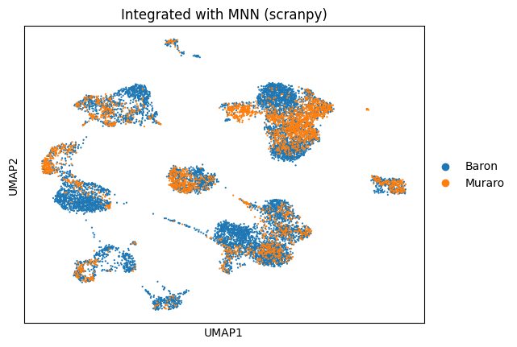

```python
import scranpy
import scanpy as sc

# 1. Prepare the data
# MNN usually works best on the PCA representation
pcs = adata.obsm['X_pca']
batches = adata.obs['study'].tolist()

# 2. Run the MNN correction
# This identifies mutual neighbors and aligns the PCA space
mnn_out = scranpy.correct_mnn(pcs.T, batches)

# 3. Store the result back in our AnnData object
# We store it in a new 'obsm' slot
adata.obsm['X_pca_mnn'] = mnn_out["corrected"].T

# 4. Visualize the result
sc.pp.neighbors(adata, use_rep='X_pca_mnn')
sc.tl.umap(adata)
sc.pl.umap(adata, color=['study'], title='Integrated with MNN (scranpy)')
```

**MNN vs. Harmony: Which one should you pick?**

[output not shown]

**The Final “Sanity Check”**

After using MNN, always look at your UMAP. If the T-cells from all studies are now in one big “island” (meaning they are integrated), but you can still see distinct sub-clusters for “CD4+” and “CD8+” (meaning the biology is preserved), your integration was successful.

```
WARNING: The title list is shorter than the number of panels. Using 'color' value instead for some plots.
```

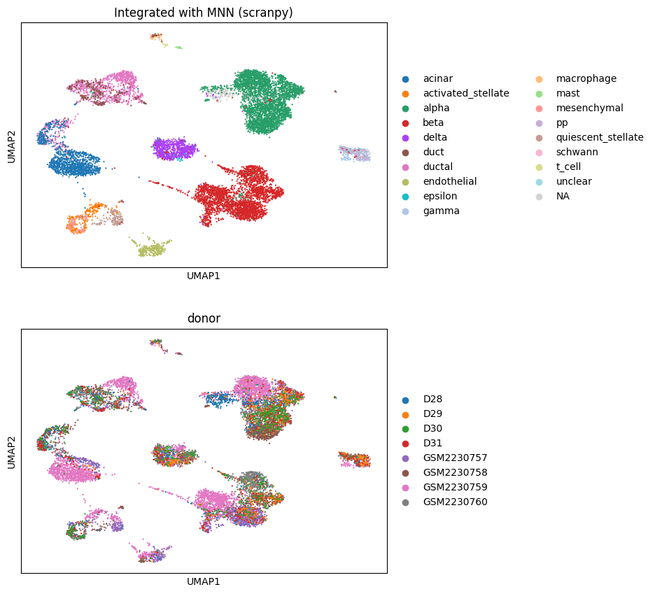

```python
sc.pl.umap(
    adata,
    color=['label', "donor"],
    title='Integrated with MNN (scranpy)',
    ncols=1
)
```

**Beyond Studies: Addressing Inter-Individual Heterogeneity**

While integrating data from entirely different studies is a common high-level task, batch effects are often more insidious, lurking within a single experiment across different individual donors. In clinical settings—particularly in datasets from leukemia patients—technical variance in sample processing, time of collection, or the unique immunological landscape of each patient can create strong “donor-specific” clusters. These technical artifacts can easily be mistaken for biological subtypes if not properly addressed. In this final exercise, we will load a multi-donor leukemia dataset to observe how these donor effects manifest in the raw latent space. We will then compare two popular integration strategies: Scanorama, which attempts to find “mutual nearest neighbors” between donors, and Harmony, which uses a soft-clustering approach to iteratively project cells into a shared space. Our goal is to determine which method most effectively merges common biological populations without erasing the meaningful disease signal we are trying to study.

```python
import scvi
import cellxgene_census
import os
from pathlib import Path

# Replace with the ID from your CELLxGENE URL
dataset_id = "b3a5a10f-b1cb-4e8e-abce-bf345448625b"

data_dir = ("/home/rstudio/project/02_batch_integration/data")

if os.path.exists(data_dir + "/" + "leukemia.h5ad"):
    print("File already exists, skipping download.")

    adata = sc.read_h5ad(data_dir + "/" + "leukemia.h5ad")
else:
    cellxgene_census.download_source_h5ad(dataset_id, to_path=data_dir + "/" + "leukemia.h5ad")
    adata = sc.read_h5ad(data_dir + "/" + "leukemia.h5ad")
```

```
File already exists, skipping download.
```

```
WARNING: The title list is shorter than the number of panels. Using 'color' value instead for some plots.
```

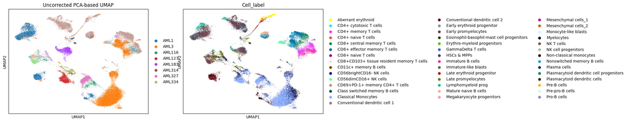

[output not shown]

[output cut: 53 more lines]

[output not shown]

```
WARNING: The title list is shorter than the number of panels. Using 'color' value instead for some plots.
```

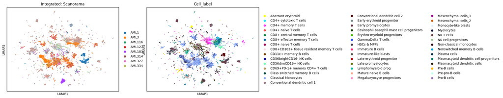

```
WARNING: The title list is shorter than the number of panels. Using 'color' value instead for some plots.
```

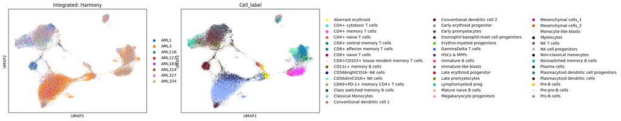

```python
import scanpy as sc
import scanpy.external as sce
import harmonypy

# 1. Load and Preprocess
sc.pp.highly_variable_genes(adata, n_top_genes=2000)
sc.pp.pca(adata)

# 2. Raw Analysis (No Integration)
# We observe how donors separate before correction
sc.pp.neighbors(adata, use_rep="X_pca")
sc.tl.umap(adata)
sc.pl.umap(adata, color=["donor_id", "Cell_label"], title="Uncorrected PCA-based UMAP")

# 3. Scanorama Integration
# Step 1: Contiguous sorting is mandatory for Scanorama
adata = adata[adata.obs.sort_values('donor_id').index].copy()

# Step 2: Run integration and recalculate manifold
sce.pp.scanorama_integrate(adata, key='donor_id')
sc.pp.neighbors(adata, use_rep='X_scanorama')
sc.tl.umap(adata)
sc.pl.umap(adata, color=["donor_id", "Cell_label"], title="Integrated: Scanorama")

# 4. Harmony Integration
# We use the manual harmonypy wrapper to ensure compatibility
# This corrects the PCA space directly
harmony_out = harmonypy.run_harmony(adata.obsm["X_pca"], adata.obs, "donor_id")
adata.obsm["X_pca_harmony"] = harmony_out.Z_corr # Note the transpose for correct shape

# Step 2: Recalculate manifold using the Harmony coordinates
sc.pp.neighbors(adata, use_rep='X_pca_harmony')
sc.tl.umap(adata)
sc.pl.umap(adata, color=["donor_id", "Cell_label"], title="Integrated: Harmony")
```